# NOTES FROM: Data Challenge with Andrew Ba Tran and Hadley Wickham - 2018-08-17

```r
# add these to yaml for pdf or github README
# output: hrbrthemes::ipsum_pdf
# output: github_document
knitr::opts_chunk$set(echo = TRUE,
                      tidy = FALSE,
                      # dev = "cairo_pdf",
                      size = "small",
                      eval = TRUE,
                      warning = FALSE,
                      message = FALSE
                      )
library(hrbrthemes)
library(ggplot2)
library(Cairo)
library(extrafont)
```

```r
# extrafont::loadfonts() # for PDF fonts
```

# Overview

This is a ‘code-through’ of the [Google Hangout](https://www.youtube.com/watch?v=tHszX31_r4s) with Hadley Wickham from the [tidyverse](https://www.tidyverse.org/) Andrew Ba Tran from the Washington Post.

Andrew has a great intro to R for Journalism course available [here](https://journalismcourses.org/), and [Hadley](http://hadley.nz/) is the Chief Scientist at RStudio.

### Thoughts on useful functions or tips

> Hadley: so one function that’s not that new but this is super helpful and not enough people know about is `case_when` so often which you basically use if you want instead of doing a bunch of `if_else` nested `if_else` statements.

> Hadley: it so it makes it really easy to do complicated transformations across multiple variables.

> Hadley: so sometimes if you see people using `if_else` inside of `if_else` s you can replace that with one `case_when`.

> Hadley: which is much much easier to understand and so what is the best way to give feedback on packages or is it by filing a Github issue or tweeting at people.

### Quotes on R language itself

> Hadley: it just still so blows my mind when I started using our weird little niche language that only statisticians used and no one else never heard about it.

> Hadley: and even in statistics people didn’t really talk about their code that much…more about you know the mathematical statistics and fitting models and stuff and I how about how you actually did it using software.

> Hadley: so it’s been really really exciting for me just to see it explode in popularity and to be used in so many different domains.

> Hadley: I particularly enjoy seeing R and in general and quantitative thinking and data science skills move out into disciplines that traditionally have not been that quantitative.

> Hadley: I think it sort of I think it’s fair to say that most people don’t become journalists because they love math and programming, but it turns out that those are really useful skills for understanding the world and what people are doing.

### What is what’s your favorite band and what’s the best music to write R?

> Hadley: I don’t know I already have a favorite band that’s disappointing I just basically pick some fairly up the poppy playlist on Apple music and listen to it it’s my usual technique or if I’m trying to you normally if I’m if I’m writing a book or something I don’t listen to music or if I do listen to music I pick something that doesn’t have English lyrics otherwise it interferes a bit too much with thinking but I do we’re also just when I’m card in place and pop music something happy come okay energetic

### Where do you see R going and what would you love to see contributors focus on building or expanding on in the next 5 years particularly in the realm of mapping?

> Hadley: I think for mapping in particular there’s a lot of things where the pieces are all there and if you’re really dedicated you can take those pieces and assemble them into something amazing. It might take you a bunch of Googling and Stack Overflow questions, or banging your head against the wall, and so I’m interested in how people take these pieces that are annoying and high friction and wrap them up into packages and make them easy to use, and document the way they work.

> Hadley: I think that’s one of the neat things about R ecosystem–that people are contributing from all these different domains solving all of these different problems.

> Hadley: Most the people using our and most people writing packages are not professional software developers or software engineers. I think this is one of the most awesome things about R, but it can also be one of the scariest things, because you’re using code maybe that hasn’t been written by someone trained in computer science, but instead by someone who is a great social scientist or a great biologist.

> Hadley: and so I think I’m just really excited, one of the things I spend a lot of my time is thinking about is how can we help people who want to write package our packages upscale, or how can we make it as easy as possible to write an R package. And then how can we make sure you can learn the smallest amount of software engineering best practices, so that you feel confident using the package.

> Hadley: and so they are making sure all these pieces fit together really smoothly.

> Hadley: some of you know that me and my team work on these [packages] directly, and then there’s just this huge ecosystem of other packages so I think hopefully, over time, get better and better and easier and easier to use.

### What would be interesting to know more about the possibilities for creating interactive visualizations for web?

> Hadley: I think the easiest way to do those with R is with `plotly` package. If you already know how to use `ggplot2`, you can basically use the same `ggplot` syntax and then just plotly-fy at the end and turn it into an interactive graphic.

### What do you think are the most common thing data journalists should know when using R?

> Hadley: one of the most important skills that anyone should have really is the abilities knowing how to get help.

> Hadley: knowing how to frame your problem to make it as easy as possible for other people to help you

> Hadley: the `reprex` package by Jenny Bryan short for a reproducible example is basically a package that allows you to take a snippet of code and rerun it in a completely independent session.

### Most R packages are collection of related tools and functions, but can a single project be organized as a package or maximum reproducibility and documentation?

> Hadley: it can be I think it’s probably a good idea although the tools at the moment are a little bit fragile and hard to work with

### Is there a good website where beginners can ask questions about R? Because the answers on Stack Overflow are often too advanced to understand…

> Hadley: the RRtudio community site. So we’re not gonna guarantee that you’ll get your question answered but at least there I think you’ll find people who will sympathize with you and share their experiences and work together to get a solution.

### Any advice for people who want to learn R but are intimidated because they have no programming experience?

> Hadley: So I think first of all, even people with no programming experience, it’s totally possible to learn R. And I think when you learn R, it’s easy to get frustrated and think, “oh it’s me I’m just not capable of learning this.” But everyone who tries to learn–no matter how smart they are, no matter how familiar they are with other programming languages–gets frustrated when they get started. So don’t let that initial frustration put you off. It happens to absolutely everyone and it’s going to happen for a while. But the good news is that it gets better over time.

> Hadley: So my first piece of advice is to acknowledge that you’re gonna get frustrated and it’s going to be annoying, that happens to everyone. I think related to this, is the best thing you can do is **find other people you and learn together. Because learning with friends just makes it just the whole experience so vastly more enjoyable.**

### How did you get into R originally?

> Hadley: I was doing my undergraduate and statistics at the University of Auckland, which was a home of R. So pretty much every class in statistics class I taught used R. I think I had one that used SAS, which I did not enjoy very much.

> Hadley: But they all pretty much used R. I think one of the reasons that I got into R, is I had sort of a fairly decent programming background. I was also doing my bachelor’s in computer science at the same time, and one of the things that I found appealing about R is that was so weird and so different to anything I’d used before. But it was clearly so useful to this group of people and the weirdness got me and got me intrigued and made me want to figure out why is R this way, and what makes it special.

# Data Science Challenge

The website being used is here:

https://extapps2.oge.gov/201/Presiden.nsf/PAS%20Filings%20by%20Date?OpenView

These data are in a table, so this is good news.

> Andrew: I would focus on the annual and then 2018.

> Hadley: Let’s dig into one of these [hyperlinks] to see; this is a PDF that has a bunch of information about this person, who they got money from, and where their retirement savings.

> Hadley: Okay so there’s two goals: the first goal is to just get a copy of all of these PDFs locally because you can see there’s a bunch of them here and ideally you wouldn’t have to go through and click through every single one of those. Once we have downloaded them, can we figure out how to turn those PDFs into some data that we can analyze somehow. When I look at this page I feel fairly certain these data look like it’s in a table, which is good news because if you’ve got a table full of data it’s much easier to get started.

## STEP 1: Download the page

```r
library(tidyverse)
library(rvest)
library(XML)
library(xml2)
```

> Hadley: So if you’re scraping anything from the web, it’s good to get familiar with the inspector in your web browser. So here’s an inspector, and you can see this is just revealing the tree structure of HTML. You can see–luckily–this all is in the table.

Check out this example of an HTML inspector

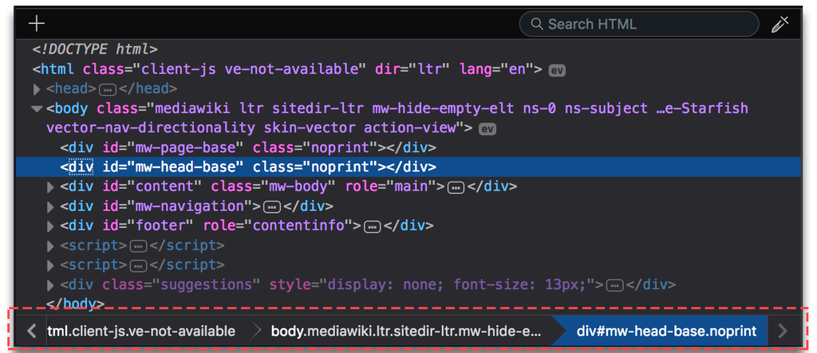

> Hadley: Okay, so that’s good news. Now I’m gonna have a go at getting that table into R. To do that I’m gonna use the `rvest` package. Hopefully, I remember how to use this. I’m going to start just by scraping this whole HTML …and I’ve forgotten how to use this…yeah, it’s giving me a warning about `read_html()`–which don’t seem to exist. Which is odd…oh maybe I’m supposed to use `XML` to read HTML (use `xml2`). So now I got a copy of this `page` and all I managed to do is download it, and so I can access it from R.

```r
page <- xml2::read_html("https://extapps2.oge.gov/201/Presiden.nsf/PAS%20Filings%20by%20Date?OpenView")
glimpse(page, 78)
```

```
List of 2
 $ node:<externalptr>
 $ doc :<externalptr>
 - attr(*, "class")= chr [1:2] "xml_document" "xml_node"
```

Now we can use the `html` table function.

> Hadley: Then because it has a table, my life’s easier, I can use this HTML table function. I’m just going to call this **Table**.

```r
table <- rvest::html_table(page)
# View(table)
class(table)
```

```
[1] "list"
```

> Hadley: Okay, so that contained a list which is my table. You can see this looks pretty good right now. You can see the day, you can see the date, you can see the name of the report, and the Justice it was from. So one problem though is that it doesn’t have the link to the HTML.

See that this is a list–use some bracket sub-setting to get the first item in the list.

```r
Table <- rvest::html_table(page)[[1]]
# convert to tibble
PFDRTable <- tibble::as_tibble(Table)
PFDRTable %>% dplyr::glimpse(78)
```

```
Observations: 944
Variables: 5
$ X1 <chr> "09/20/2018", "09/19/2018", "09/18/2018", "09/13/2018", "08/23/2…
$ X2 <chr> "Annual (2018)", "Annual (2018)", "278 Transaction (09/18/2018)"…
$ X3 <chr> "Quarles, Randal K", "Censky, Stephen L.", "Shanahan, Patrick M"…
$ X4 <chr> "Federal Reserve System Board of Governors", "Department of Agri…
$ X5 <chr> "Governor & Vice Chairman for Supervision", "Deputy Secretary", …
```

> Hadley: I’m going to name these columns, so it’s going to be a little bit easier.

Assign some names to the tibble.

```r
base::names(PFDRTable) <- c("date", "report", "name", "department", "position")
PFDRTable %>% dplyr::glimpse(78)
```

```
Observations: 944
Variables: 5
$ date       <chr> "09/20/2018", "09/19/2018", "09/18/2018", "09/13/2018", …
$ report     <chr> "Annual (2018)", "Annual (2018)", "278 Transaction (09/1…
$ name       <chr> "Quarles, Randal K", "Censky, Stephen L.", "Shanahan, Pa…
$ department <chr> "Federal Reserve System Board of Governors", "Department…
$ position   <chr> "Governor & Vice Chairman for Supervision", "Deputy Secr…
```

## STEP 2: Where do the links end up?

> Hadley: Okay and then the other thing I have to do is I have to figure out where all of these links go. So one way of doing that, which I use a lot, is this app called selector gadget.

Install the [selector gadget](https://selectorgadget.com/).

> Hadley: When I load selector gadget, what I’m going to do is I’m going to click on the thing that I want to extract, it’s going to come up with a candidate expression. You can see it’s got some false positives, so I’d only want the links in here. I don’t want the links at the top, so I can say, ‘don’t pick those’ and then it comes up with a new rule, and that rule looks pretty good. So the rule is expressed as a CSS selector, which is saying look for something in the HTML that has an ID called `index` and then find all of the `a` tags or the link tags inside of that.

After clicking on the hyperlink, and clicking on the false positive (in red), we learn we are looking for the `#index a` html node. Now we add this to the initial extract.

```r
Page <- xml2::read_html("https://extapps2.oge.gov/201/Presiden.nsf/PAS%20Filings%20by%20Date?OpenView")
Page %>%
    rvest::html_nodes("#index a") %>%
    rvest::html_attr("href") %>% length()
```

```
[1] 945
```

> Hadley: So now in `Page` we can say `html_nodes()`–let’s just see if this works–that’s perfect. You can see this is going to extract 942 links–this goes to me the `a` tag–which has the place of the links to the text, and then I want to extract the `href` attribute, which has the link.

This returns 945 rows, which is higher than the number of rows in our table.

```r
PFDRTable %>% nrow()
```

```
[1] 944
```

This means we need a different node to extract with.

> Hadley: Okay so now I have 942 links, but I only have 941 rows in this table which is a little sad. It looks I’ve got an extra link somewhere…now I bet one of these has two links.

> Hadley: So what I’m going to do is instead of starting with a link…I am going to start with the table cells (`#index td a`)…

```r
Page %>%
    # this is the same as above
    rvest::html_nodes("#index td a") %>%
    rvest::html_attr("href") %>%
    base::length()
```

```
[1] 945
```

> Hadley: I don’t want the table cells (`"#index tr"`), I’m going to start with the table rows, and hopefully, they’re 941 of those.

```r
Page %>%
    # this is the table row
    rvest::html_nodes("#index tr") %>%
    # get the hyperlink
    rvest::html_node("a") %>%
    # this is the header reference
    rvest::html_attr("href") %>%
    base::length()
```

```
[1] 944
```

BINGO! Put these 944 URLs into the tibble. Notice that the entire piping operation is to generate a single column of urls that can be added to the `PFDRTable` (that’s why the length had to identical to the number of rows in the table).

```r
PFDRTable$url <- Page %>%
    # this is the table row
    rvest::html_nodes("#index tr") %>%
    # get the hyperlink
    rvest::html_node("a") %>%
    # this is the header reference
    rvest::html_attr("href")
PFDRTable %>% glimpse(78)
```

```
Observations: 944
Variables: 6
$ date       <chr> "09/20/2018", "09/19/2018", "09/18/2018", "09/13/2018", …
$ report     <chr> "Annual (2018)", "Annual (2018)", "278 Transaction (09/1…
$ name       <chr> "Quarles, Randal K", "Censky, Stephen L.", "Shanahan, Pa…
$ department <chr> "Federal Reserve System Board of Governors", "Department…
$ position   <chr> "Governor & Vice Chairman for Supervision", "Deputy Secr…
$ url        <chr> "https://extapps2.oge.gov/201/Presiden.nsf/PAS+Index/CC6…
```

## STEP 3: Check the 2018 reports

Now check the `Annual (2018)` reports with `dplyr::count()`.

```r
PFDRTable %>%
    dplyr::count(report, sort = TRUE) %>%
    View()
```

Note that Hadley *visually inspects the data a lot to verify what the code has done what he was expecting*.

> Hadley: I think Andrew said that we only mostly care about the annual report in 2018

> Hadley: One thing I often worry about is sometimes you have a space at the end, and there’s no way to see that…yeah you can’t tell if there’s a space, so it’s a good idea just to look at it…I’m just going to look at all of them and just skim down to see if there are any others that maybe I’m going to miss.

> Hadley: let’s just check what they all are…I’m just going to `count` them up…

```r
PFDRTable %>%
    dplyr::filter(stringr::str_detect(report, "Annual")) %>%
    dplyr::count(report, sort = TRUE) %>%
    utils::head(10)
```

| report | n |
| --- | --- |
| Annual (2016) | 53 |
| Annual (2015) | 50 |
| Annual (2014) | 46 |
| Annual (2013) | 43 |
| Annual (2018) | 32 |
| Annual (2012) | 14 |
| Annual Term | 10 |
| Annual (2017) | 8 |

This is a great use of `dplyr::pull()` to check `dplyr::filter()` results.

```r
PFDRTable %>%
    dplyr::filter(report == "Annual (2018)") %>%
    dplyr::pull(url) %>%
    utils::head(10)
```

```
 [1] "https://extapps2.oge.gov/201/Presiden.nsf/PAS+Index/CC6057396B5CBEB88525830F002952B8/$FILE/Randal-K-Quarles-2018-278.pdf"
 [2] "https://extapps2.oge.gov/201/Presiden.nsf/PAS+Index/94E7D47752213EE48525830E00294FBB/$FILE/Stephen-L-Censky-2018-278.pdf"
 [3] "https://extapps2.oge.gov/201/Presiden.nsf/PAS+Index/6F0277ABD5BE0DCA8525830800294DF9/$FILE/Lael-Brainard-2018-278.pdf"
 [4] "https://extapps2.oge.gov/201/Presiden.nsf/PAS+Index/4C821E2D25E73DEF852582F000568CFF/$FILE/Ryan-Zinke-2018-278.pdf"
 [5] "https://extapps2.oge.gov/201/Presiden.nsf/PAS+Index/FE3E51A62D7D2B05852582F100293AE9/$FILE/Rod-J-Rosenstein-2018-278.pdf"
 [6] "https://extapps2.oge.gov/201/Presiden.nsf/PAS+Index/DDDA0D112B138EA5852582EC00294821/$FILE/Jefferson-B-Sessions-2018-278.pdf"
 [7] "https://extapps2.oge.gov/201/Presiden.nsf/PAS+Index/B72D7D1FA55C671A852582D8002945C2/$FILE/France-A-Cordova-2018-278.pdf"
 [8] "https://extapps2.oge.gov/201/Presiden.nsf/PAS+Index/D7C281310C8D1705852582D80029458D/$FILE/Benjamin-S-Carson-Sr-2018-278.pdf"
 [9] "https://extapps2.oge.gov/201/Presiden.nsf/PAS+Index/4BDACABDEF9D34E9852582D40029415B/$FILE/William-B-Long-2018-278.pdf"
[10] "https://extapps2.oge.gov/201/Presiden.nsf/PAS+Index/3DC14CE973BE1FBD852582D100294239/$FILE/George-E-Perdue-2018-278.pdf"
```

> Hadley: So I’m fairly confident that if I do exactly those, I’m going to get the right thing.

> Hadley: Okay, so I’ve got all of these and then I could just pull out those URLs and now I want to download them somewhere.

Put these into a table.

```r
Annual2018 <- PFDRTable %>% dplyr::filter(report == "Annual (2018)")
Annual2018 %>% dplyr::glimpse(78)
```

```
Observations: 32
Variables: 6
$ date       <chr> "09/20/2018", "09/19/2018", "09/13/2018", "08/21/2018", …
$ report     <chr> "Annual (2018)", "Annual (2018)", "Annual (2018)", "Annu…
$ name       <chr> "Quarles, Randal K", "Censky, Stephen L.", "Brainard, La…
$ department <chr> "Federal Reserve System Board of Governors", "Department…
$ position   <chr> "Governor & Vice Chairman for Supervision", "Deputy Secr…
$ url        <chr> "https://extapps2.oge.gov/201/Presiden.nsf/PAS+Index/CC6…
```

#### Hidden gem: the `basename()` function!

In order to save the files, we need to figure out the names for them.

> Hadley: If I’m going to download them… I’m going to want to come up with a file name and so I think just using the same file name here…and I think the easiest let’s just try what they’re called…good…yeah I can use this `basename()` function which I happen to know about.

```r
base::basename(Annual2018$url) %>% utils::head(5)
```

```
[1] "Randal-K-Quarles-2018-278.pdf" "Stephen-L-Censky-2018-278.pdf" "Lael-Brainard-2018-278.pdf"    "Ryan-Zinke-2018-278.pdf"       "Rod-J-Rosenstein-2018-278.pdf"
```

Now we can create the directory for these files.

> Hadley: I’m going to put this in the directory called PDFs.

```r
# put url in its own object
url <- Annual2018$url
# create path
path <- paste0("pdfs/", base::basename(url))
path %>% utils::head()
```

```
[1] "pdfs/Randal-K-Quarles-2018-278.pdf"     "pdfs/Stephen-L-Censky-2018-278.pdf"     "pdfs/Lael-Brainard-2018-278.pdf"
[4] "pdfs/Ryan-Zinke-2018-278.pdf"           "pdfs/Rod-J-Rosenstein-2018-278.pdf"     "pdfs/Jefferson-B-Sessions-2018-278.pdf"
```

Now we can download the files.

## STEP 4: Download files with `walk2`

Use `purrr:walk2` and `download.file` to download the pdfs.

> Hadley: Now I want to download each one of those files..`download.file()` which takes a single URL, and a single destination path, and I’ve got a bunch of files, and a bunch of URLs, so if you’re looking for one way to solve this would be with a for loop.

> Hadley: I’m just going to skip these steps, and I’m going to use this function called `map2` . And what `map2` is designed to do, is basically take–what I actually want use is something called `walk2`–it’s going to take the URLs, the `path`s it’s gonna call `download.file()` once for each URL and `path`…and before I do that I’m going to create this PDF directory.

```r
dir.create("pdfs")
purrr::walk2(.x = url, .y = path, .f = download.file)
```

### Quick Question: *When you were designing new families of functions–like highly specific functions in `purrr` –are you developing for defined problem classes or to extend along possible data structures?*

> Hadley: Part of the motivation, is I keep track of little problems that seem like they should not feel harder than they should be. I talk to people, and they can tell me what they’re struggling with, and so that’s part of it knowing what specific problems that need to be solved in general.

> Hadley: I spend a lot of takes a long time but before enough problems accumulate to figure out what the class of solutions would be, then I also read a lot about other programming languages.

> Hadley: I really making little tables–so for example–in this case–`map` and `map2`…and `walk`…and then you know sometimes you want the output to be a list and sometimes you want the output to look more like this…you’ve got `1 argument` that’s changing you’ve got `2 arguments` are changing, and you have `n arguments` changing…if you want a `list`, well that’s gonna be `map`, if you have 2 arguments and your data is in a list that’s going to be `n arguments` - and this is a `pmap`.

```
                list    int
1 argument      map
2 arguments     map2
n arguments     pmap
```

> Hadley: So I construct these little tables and try and make sure every cell is filled so thinking about all other possible combinations and can we can we solve them all in one fell swoop.

## STEP 5: Dealing with pdfs

Now we need to figure out how to get the data out of the pdfs.

### Quick sidebar to install `tabulizer`.

The package `tabulizer` was giving me a lot of trouble when loading, so I documented my steps here.

> Hadley: So I’ve downloaded them all, and I have got a bunch of PDFs. Now I have the next problem, which is I have 28 PDFs and I need to extract some information from them.

> Hadley: So this isn’t my area of expertise, but I did a little googling yesterday I think there’s two packages that you should start with: the first one is `tabulizer` which is a wrapper around this java program, and the other is `pdftools`.

> Hadley: I think you want to start with `tabulizer` because it is designed specifically to extract tables out of PDFs, and so if this works you’re good.

```r
# install.packages("tabulizer")
# install.packages("tabulizerjars")
# install.packages("rJava", ,"http://rforge.net")
library(rJava)
library(tabulizer)
library(pdftools)
```

I was getting hung up on this portion because I needed to install some additional packages (`rJava`, `tabulizerjars`).

I also needed to install `JDK` with homebrew in the terminal.

```
$ brew cask install java
Updating Homebrew...
==> Caveats
This Cask makes minor modifications to the JRE to prevent issues with
packaged applications, as discussed here:

  https://bugs.eclipse.org/bugs/show_bug.cgi?id=411361

If your Java application still asks for JRE installation, you might need
to reboot or logout/login.

Installing java means you have AGREED to the license at
  https://www.oracle.com/technetwork/java/javase/terms/license/javase-license.html

==> Satisfying dependencies
==> Downloading http://download.oracle.com/otn-pub/java/jdk/11+28/55eed80b163941
==> Downloading from http://download.oracle.com/otn-pub/java/jdk/11+28/55eed80b1
######################################################################## 100.0%
==> Verifying SHA-256 checksum for Cask 'java'.
==> Installing Cask java
==> Running installer for java; your password may be necessary.
==> Package installers may write to any location; options such as --appdir are i
Password:
installer: Package name is JDK 11
installer: Installing at base path /
installer: The install was successful.
java was successfully installed!
```

Then tried install and saw the following:

```
Make sure you have Java Development Kit installed and correctly registered in R.
If in doubt, re-run "R CMD javareconf" as root.
```

So I ran the command using `sudo` privileges.

[output not shown]

Tried the install again, no luck.

Installed the legacy Java recommended on the tabulizer [website](https://github.com/ropensci/tabulizer).

Found [this issue](https://github.com/rstudio/rstudio/issues/2254) on github and ran the following again:

```
$ sudo R CMD javareconf
```

Tried again…

```r
library(rJava)
library(tabulizer)
library(pdftools)
```

SUCCESS!!

### Back to the video….

```r
library(rJava)
library(tabulizer)
library(pdftools)
library(tabulizerjars)
# redifine path as path_1
path_1 <- "pdfs/Alexander-Acosta-2018-278.pdf"
PDFtables <- tabulizer::extract_tables(path_1)
```

[output not shown]

All kinds of crazy warnings.

[output not shown]

This is a good place to export our work thus far. Create a directory.

```r
# fs::dir_ls(".")
dir.create("data")
# fs::dir_ls("data")
dir.create("data/RData")
```

Save a time-stamped version of this data.

```r
save.image(file = paste0("data/RData/",
                         base::noquote(lubridate::today()),
                         "-rjournalism_data_challenge.RData"))
# verify
fs::dir_ls("data/RData")
```

```
data/RData/2018-09-26-rjournalism_data_challenge.RData data/RData/2018-09-27-rjournalism_data_challenge.RData
```

Check the new object.

```r
PDFtables %>% head()
```

```
[[1]]
      [,1]                                                            [,2]               [,3]              [,4]              [,5]
 [1,] "1. Filer's Positions Held Outside United States Government"    ""                 ""                ""                ""
 [2,] "# ORGANIZATION NAME CITY, STATE"                               "ORGANIZATION"     "POSITION HELD"   "FROM"            "TO"
 [3,] ""                                                              "TYPE"             ""                ""                ""
 [4,] "1 Florida International University Miami, Florida"             "University/Colle" "Dean of the"     "7/2009"          "4/2017"
 [5,] ""                                                              "ge"               "College of Law"  ""                ""
 [6,] "2 Breakthrough Miami Miami, Florida"                           "Non-Profit"       "Director"        "2/2017"          "4/2017"
 [7,] "3 Gulliver Schools Miami, Florida"                             "Non-Profit"       "Trustee"         "11/2016"         "4/2017"
 [8,] "4 U.S. Century Bank Miami, Florida"                            "Corporation"      "Chair, Board of" "11/2013"         "4/2017"
 [9,] ""                                                              ""                 "Directors"       ""                ""
[10,] "5 American Bar Association Commission on Chicago, Illinois"    "Professional"     "Chairman"        "8/2015"          "4/2017"
[11,] "Hispanic Legal Rights and Responsibilities"                    "Organization"     ""                ""                ""
[12,] ""                                                              ""                 ""                ""                ""
[13,] "2. Filer's Employment Assets & Income and Retirement Accounts" ""                 ""                ""                ""
[14,] "# DESCRIPTION EIF"                                             "VALUE"            "INCOME TYPE"     "INCOME"          ""
[15,] ""                                                              ""                 ""                "AMOUNT"          ""
[16,] "1 Florida International University N/A"                        ""                 "Salary (2017)"   "$151,438"        ""
[17,] "2 U.S. Century Bank, 150,000 warrants, $1.50 N/A"              "$100,001 -"       ""                "None (or less"   ""
[18,] "strike price, vested as follows: 100,000 on"                   "$250,000"         ""                "than $201)"      ""
[19,] "3/1/16; 50,000 on 3/1/17."                                     ""                 ""                ""                ""
[20,] "3 U.S. Century Bank N/A"                                       ""                 "Director Fees"   "$23,000"         ""
[21,] ""                                                              ""                 "(2017)"          ""                ""
[22,] "4 CREF Growth Yes"                                             "$250,001 -"       ""                "None (or less"   ""
[23,] ""                                                              "$500,000"         ""                "than $201)"      ""
[24,] "5 CREF Global Equities Yes"                                    "$250,001 -"       ""                "None (or less"   ""
[25,] ""                                                              "$500,000"         ""                "than $201)"      ""
[26,] "6 TIAA Traditional Annuity N/A"                                "$50,001 -"        "Interest"        "$1,001 - $2,500" ""
[27,] ""                                                              "$100,000"         ""                ""                ""
```

Extract this list into a table.

> Hadley: so I’ve got this object back…I don’t know what type of object it is. Whenever that happens to me, I use `str()` or i use `View(PDFtables)` or use `View()` until you can see this is a list of length one…so that presumably implies that it loaded one table, and each table is a matrix so let’s just extract that take a look.

```r
PDFtables[[1]]
```

```
      [,1]                                                            [,2]               [,3]              [,4]              [,5]
 [1,] "1. Filer's Positions Held Outside United States Government"    ""                 ""                ""                ""
 [2,] "# ORGANIZATION NAME CITY, STATE"                               "ORGANIZATION"     "POSITION HELD"   "FROM"            "TO"
 [3,] ""                                                              "TYPE"             ""                ""                ""
 [4,] "1 Florida International University Miami, Florida"             "University/Colle" "Dean of the"     "7/2009"          "4/2017"
 [5,] ""                                                              "ge"               "College of Law"  ""                ""
 [6,] "2 Breakthrough Miami Miami, Florida"                           "Non-Profit"       "Director"        "2/2017"          "4/2017"
 [7,] "3 Gulliver Schools Miami, Florida"                             "Non-Profit"       "Trustee"         "11/2016"         "4/2017"
 [8,] "4 U.S. Century Bank Miami, Florida"                            "Corporation"      "Chair, Board of" "11/2013"         "4/2017"
 [9,] ""                                                              ""                 "Directors"       ""                ""
[10,] "5 American Bar Association Commission on Chicago, Illinois"    "Professional"     "Chairman"        "8/2015"          "4/2017"
[11,] "Hispanic Legal Rights and Responsibilities"                    "Organization"     ""                ""                ""
[12,] ""                                                              ""                 ""                ""                ""
[13,] "2. Filer's Employment Assets & Income and Retirement Accounts" ""                 ""                ""                ""
[14,] "# DESCRIPTION EIF"                                             "VALUE"            "INCOME TYPE"     "INCOME"          ""
[15,] ""                                                              ""                 ""                "AMOUNT"          ""
[16,] "1 Florida International University N/A"                        ""                 "Salary (2017)"   "$151,438"        ""
[17,] "2 U.S. Century Bank, 150,000 warrants, $1.50 N/A"              "$100,001 -"       ""                "None (or less"   ""
[18,] "strike price, vested as follows: 100,000 on"                   "$250,000"         ""                "than $201)"      ""
[19,] "3/1/16; 50,000 on 3/1/17."                                     ""                 ""                ""                ""
[20,] "3 U.S. Century Bank N/A"                                       ""                 "Director Fees"   "$23,000"         ""
[21,] ""                                                              ""                 "(2017)"          ""                ""
[22,] "4 CREF Growth Yes"                                             "$250,001 -"       ""                "None (or less"   ""
[23,] ""                                                              "$500,000"         ""                "than $201)"      ""
[24,] "5 CREF Global Equities Yes"                                    "$250,001 -"       ""                "None (or less"   ""
[25,] ""                                                              "$500,000"         ""                "than $201)"      ""
[26,] "6 TIAA Traditional Annuity N/A"                                "$50,001 -"        "Interest"        "$1,001 - $2,500" ""
[27,] ""                                                              "$100,000"         ""                ""                ""
```

Now we call the extraction `Lines`, then convert to tibble named `Acosta`.

```r
Lines <- PDFtables[[1]]
Acosta <- tibble::as_tibble(Lines)
Acosta %>% utils::head()
```

| V1 | V2 | V3 | V4 | V5 |
| --- | --- | --- | --- | --- |
| 1. Filer's Positions Held Outside United States Government |  |  |  |  |
| # ORGANIZATION NAME CITY, STATE | ORGANIZATION | POSITION HELD | FROM | TO |
|  | TYPE |  |  |  |
| 1 Florida International University Miami, Florida | University/Colle | Dean of the | 7/2009 | 4/2017 |
|  | ge | College of Law |  |  |
| 2 Breakthrough Miami Miami, Florida | Non-Profit | Director | 2/2017 | 4/2017 |

Sheesh–many tables in a single PDF.

Assign some names to this table.

> Hadley: So here is the first table see you can see this this looks promising…you can see we’ve got each cell on the table, and it’s lined up…we have this little problem it’s you can see `college university`… `colleges` got split up into two lines, but this seems maybe we’ve got two tables jammed into this table…this seems…a worthwhile place to start.

> Hadley: I’m going to call this Acosta…that’s a terrible idea because I will systematically type it wrong every single time..and again I’m going to name those variables so it looks the first column is organization, (`org`),`type`, and `position` … and so then the next thing I want to do I think let’s just view this again. What’s happened is I think we’ve actually got multiple tables in here…so I think a good place to start is to try and just work on a single table.

```r
names(Acosta) <- c("org", "type", "position", "from", "to")
Acosta
```

| org | type | position | from | to |
| --- | --- | --- | --- | --- |
| 1. Filer's Positions Held Outside United States Government |  |  |  |  |
| # ORGANIZATION NAME CITY, STATE | ORGANIZATION | POSITION HELD | FROM | TO |
|  | TYPE |  |  |  |
| 1 Florida International University Miami, Florida | University/Colle | Dean of the | 7/2009 | 4/2017 |
|  | ge | College of Law |  |  |
| 2 Breakthrough Miami Miami, Florida | Non-Profit | Director | 2/2017 | 4/2017 |
| 3 Gulliver Schools Miami, Florida | Non-Profit | Trustee | 11/2016 | 4/2017 |
| 4 U.S. Century Bank Miami, Florida | Corporation | Chair, Board of | 11/2013 | 4/2017 |
|  |  | Directors |  |  |
| 5 American Bar Association Commission on Chicago, Illinois | Professional | Chairman | 8/2015 | 4/2017 |

[output cut: 17 more lines]

We can start cleaning with `stringr::str_which()`.

> Hadley: So `str_which` is gonna tell me all the lines, and the pattern I’m going to look for is `1. Filer's Position`.

The `stringr::str_which()` function lets us index on a particular string. We can see more about how this works using another `stringr` function, `stringr::str_detect()`

```r
# find the string in Acosta
Acosta %>%
  dplyr::filter(stringr::str_detect(string = org,
                                    pattern = "1. Filer's Position"))
```

| org | type | position | from | to |
| --- | --- | --- | --- | --- |
| 1. Filer's Positions Held Outside United States Government |  |  |  |  |

```r
Acosta %>%
  dplyr::filter(stringr::str_detect(string = org,
                                    pattern = "2. Filer's Employment"))
```

| org | type | position | from | to |
| --- | --- | --- | --- | --- |
| 2. Filer's Employment Assets & Income and Retirement Accounts |  |  |  |  |

> Hadley: So you know if you’re doing this, there’s no good way…you just have to try something, and then see how it works. You’re going to have some positives, and you might have some false negatives, but get something that works for one document.

```r
acosta_line_1 <- stringr::str_which(Acosta$org, "1. Filer's Position")
acosta_line_1
```

```
[1] 1
```

```r
acosta_line_2 <- stringr::str_which(Acosta$org, "2. Filer's Employment")
acosta_line_2
```

```
[1] 13
```

These two integers can be used to subset the `Acosta` table with `dplyr::slice()`.

```r
Acosta %>% slice((acosta_line_1 + 3):(acosta_line_2 - 2))
```

| org | type | position | from | to |
| --- | --- | --- | --- | --- |
| 1 Florida International University Miami, Florida | University/Colle | Dean of the | 7/2009 | 4/2017 |
|  | ge | College of Law |  |  |
| 2 Breakthrough Miami Miami, Florida | Non-Profit | Director | 2/2017 | 4/2017 |
| 3 Gulliver Schools Miami, Florida | Non-Profit | Trustee | 11/2016 | 4/2017 |
| 4 U.S. Century Bank Miami, Florida | Corporation | Chair, Board of | 11/2013 | 4/2017 |
|  |  | Directors |  |  |
| 5 American Bar Association Commission on Chicago, Illinois | Professional | Chairman | 8/2015 | 4/2017 |
| Hispanic Legal Rights and Responsibilities | Organization |  |  |  |

> Hadley: And if you’re gonna do this 100% `tidyverse` you could use `slice`…huh there might be a bug in `slice` so I’m going to take it a different way…I’m just going to use old school subsetting.

```r
# Acosta %>% dplyr::slice((acosta_line_1 + 3):(acosta_line_2 - 2))
AcostaPosition <- Acosta[(acosta_line_1 + 3):(acosta_line_2 - 2), ]
AcostaPosition
```

| org | type | position | from | to |
| --- | --- | --- | --- | --- |
| 1 Florida International University Miami, Florida | University/Colle | Dean of the | 7/2009 | 4/2017 |
|  | ge | College of Law |  |  |
| 2 Breakthrough Miami Miami, Florida | Non-Profit | Director | 2/2017 | 4/2017 |
| 3 Gulliver Schools Miami, Florida | Non-Profit | Trustee | 11/2016 | 4/2017 |
| 4 U.S. Century Bank Miami, Florida | Corporation | Chair, Board of | 11/2013 | 4/2017 |
|  |  | Directors |  |  |
| 5 American Bar Association Commission on Chicago, Illinois | Professional | Chairman | 8/2015 | 4/2017 |
| Hispanic Legal Rights and Responsibilities | Organization |  |  |  |

> Hadley: I think this looks typical when you’re doing data analysis…you’re writing code, you jump around quite a bit, and that’s fine. The main thing is to get it working, and then come back and do another pass through where you comment so you can remember what you what you’re doing…and you can come back in the future…but now I think we’ve got a decent subset.

## STEP6: Tackling large data analysis/projects

> Hadley: *I think it’s whenever you’re tackling a big problem like this…you should start with ruthlessly narrowing down the problem until you can actually solve it.* So I’m ruthlessly narrowing it down to get one single table worth of data, and I seem to have done that, and so I was adjusting these offsets here to say basically how many lines so I want to trim, and I’m just going to do it–I’m just doing that until I don’t see any empty lines at the top or the bottom.

Now we have the table `AcostaPosition` with some of the `to` and `from` rows missing, and this is because the `type` and `position` columns occaisionally spill over into the next row (like `University/College` and `Dean of the College of Law`)

```r
AcostaPosition
```

| org | type | position | from | to |
| --- | --- | --- | --- | --- |
| 1 Florida International University Miami, Florida | University/Colle | Dean of the | 7/2009 | 4/2017 |
|  | ge | College of Law |  |  |
| 2 Breakthrough Miami Miami, Florida | Non-Profit | Director | 2/2017 | 4/2017 |
| 3 Gulliver Schools Miami, Florida | Non-Profit | Trustee | 11/2016 | 4/2017 |
| 4 U.S. Century Bank Miami, Florida | Corporation | Chair, Board of | 11/2013 | 4/2017 |
|  |  | Directors |  |  |
| 5 American Bar Association Commission on Chicago, Illinois | Professional | Chairman | 8/2015 | 4/2017 |
| Hispanic Legal Rights and Responsibilities | Organization |  |  |  |

> Hadley: so now we have the next problem which is some of these lines are not actually just carried over from the previous line this line with the type as `ge` clearly. what I should be doing is pasting that together with the previous line…

Then Andrew chimes in about twitter.

> Andrew: I’m pretty sure I tweeted about this

> Andrew: you mutate fill and filter and you use direction up or down…fill and direction…

Twitter is an excellent resource for quick #rstats answers–many times I end up reweeting or emailing myself bits of code to save for later.

> Hadley: …and this is a slightly different problem isn’t it? oh yeah so let me…I’m just gonna write some code and then if it works…I’ll explain…I just have some intuition about how that’s might work.

The ‘intuition’ has probably been developed over time from the countless analyses Hadley’s performed, but it’s also clear to me that the functions Hadley uses have become almost second nature–he thinks *in terms* of functions and the actions they perform. This is an important step in skill acquisition and learning (see chunking). For example, I have no doubt that the verbs the tidyverse functions are based on mean something different in Hadley’s brain than mine, and he no longer has to think about the ‘thing’ he wants to be performed, and the ‘function’ he needs to use.

Below is a little more from Hadley thought process. Pay attention to how much trial and error occurs and the problems get solved bit-by-bit.

> Hadley: I’m gonna call this type 2 I’m gonna fill - yeah this and then I’m just gonna make it a little easier…just gonna narrow it down to look at these two…oh whoops that’s not how it works…okay yes now it’s slightly coming back… and let’s see how that worked…okay so all I have managed to do is put this and this…now I can…I’m just going to show you those two columns but, now you can see basically all I’ve managed to do is put it in its own column to the side and when it isn’t carried over I’ve got `NA`’s…and so now what I can do is `fill()` `type2` `up` this “`direction`”…and that is coming…I forget how to use `direction`…that would make sense…okay now I’ve got them on the same line…now I’m gonna call it `type3` so you can see what’s going on…I’m just going to combine `type` and `type2` and then print them that so you can see…

There is a lot of trying a series of steps, reorganizing, trying something else. Acknowledgment that he *doesn’t remember how* a particular function might work, but takes the time to figure it out.

> Hadley: There are some lines where I’ve ended up with nonsense…but I’m gonna get rid of that line anyway…so I don’t really care.

This is helpful–articulating what **NOT** to get hung up on.

> Hadley: Let’s just look at the whole thing again, I just solved it for one and I’m just gonna leave it there so you basically get the idea. At this point, I don’t know exactly what I have done but it seems to have worked…

This is a typical remark I find in old code of mine and on Github. I will see a series of functions with a comment that says something like, “don’t know how/why this works, but it does. DON’T TOUCH!”

> Hadley: …and so now if I was doing a real analysis I would sit down and think, “that seemed to require a lot of steps, and some of those steps I put in to explain my thinking…but I think some of them, maybe now that I’ve solved it, it’s a good opportunity to go back and say,”could I solve this better in some way?", before I go on to the next challenge.

So the steps are 1) drill the problem down to the smallest, solvable elements, 2) get something that works, and 3) come back and reevaluate later.

```r
AcostaPosition %>%
  # what is (to == "") doing?
  dplyr::mutate(carryover = (to == "")) %>%
  # what does this condition produce?
  dplyr::mutate(type2 = base::ifelse(test = carryover,
                                      yes = type,
                                      no = NA)) %>%
  # how does fill work?
  tidyr::fill(type2, .direction = "up") %>%
  # can this be done with stringr::str_c?
  dplyr::mutate(type3 = base::paste0(type, type2)) %>%
  # why do I filter out TRUE carryovers?
  dplyr::filter(!carryover) %>%
  # now look at them all to see what happened
  dplyr::select(carryover,
                type,
                type2,
                type3)
```

| carryover | type | type2 | type3 |
| --- | --- | --- | --- |
| FALSE | University/Colle | ge | University/College |
| FALSE | Non-Profit |  | Non-Profit |
| FALSE | Non-Profit |  | Non-Profit |
| FALSE | Corporation |  | Corporation |
| FALSE | Professional | Organization | ProfessionalOrganization |

Hadley also mentions turning the process into a function, but the time for this tutorial ran out.

## Other takeaways

- **He specifically mentions being able to type very fast.** Everything in this field comes down to neurons and keystrokes, and *both* of these can be improved drastically with daily practice.

Typing and organizing your workflow are the ‘fundamental basketball’ skills in data science. Hadley has even posted [videos](https://www.youtube.com/watch?v=boKFxBniUH0) showing him using applications that allow him to quickly move between the projects/files/software programs on his computer.

- **Hadley didn’t open a new project or folder.** The .Rproj file would’ve saved the day, and he acknowledges he might’ve accidentally downloaded the .pdfs into his home directory.

He also didn’t update any packages, use the .Rmd files, or introduce any other concepts outside the .R script and RStudio IDE. This is a testament to how quickly you can get started on a project with RStudio.

This was a great video to watch and learn from, and I hope both Hadley and Andrew to keep sharing their work and expertise.